# Introduction

## 5. Conventions common to the series

### 5.1. Presentation of reconstructions

Each of the contributions to these volumes concerns a particular POc ‘terminology’. Generally, each contribution begins with an introduction to the issues raised by the reconstruction of its particular terminology, and the rest consists of reconstructed etyma with supporting data and a commentary on matters of meaning and form.

The reconstruction of POc *pale below, abbreviated from Chapter 5, shows how reconstructions and supporting cognate sets are presented. Above it is a superordinate (PMP) reconstruction drawn from published sources. Below it are supporting reflexes. Sometimes a lower-order reconstruction like PMic *fale below is included, either in acknowledgment of others’ work, or because it reflects a significant change in form or meaning.

| **PMP** |  | *balay | ‘public building’ (Blust 1987); ‘unwalled building’ (Waterson 1993) |
| --- | --- | --- | --- |
| **POc** |  | *pale | ‘building for storage or public use, open-sided building, shed’ |
| Adm: | Lou | *pal* | ‘canoe hut’ |
| Adm: | Mussau | *ale* | ‘house’ |
| NNG: | Yabem | *ale* | ‘house’ |
| NNG: | Lukep (Pono) | *para* | ‘yam house’ |
| MM: | Tolai | *pal* | ‘house, room’ |
| MM: | Mono-Alu | *hale-hale* | ‘public building’ |
| SES: | Arosi | *hare* | ‘shed for yams’ (E Arosi); ‘house with side of roof only, made in garden’ (W Arosi) |
| SES: | Bauro | *hare* | ‘canoe house, men’s house’ |
| SES: | Sa’a | *hale* | ‘yam shed outside a garden’ |
| SES: | Kwaio | *fale* | ‘hut for childbirth’ |
| SES: | Gela | *hale* | ‘house’ |
| NCV: | Raga | *vale* | ‘house, hut, garden house’ |
| NCV: | Nokuku | *vale* | ‘shelter’ |
| NCV: | Nokuku | *val-val* | ‘garden shelter’ |
| **PMic** |  | *fale | ‘meeting house’ (Bender et al. 2003a) |
| Mic: | Puluwat | *fǣl* | ‘meeting house’ |
| Mic: | Woleai | *fal*, *fale-* | ‘men’s house, club house’ |
| Fij: | Bauan | *vale* | ‘house’ |
| Pn: | Samoan | *fale* | ‘house’ |
| Pn: | Hawaiian | *hale* | ‘house’ |

In putting together cognate sets, we have sometimes found apparent or uncertain reflexes which do not quite ‘fit’ the set: either they display a phonological irregularity or their meaning is just a little too different from the rest of the set for us to assume cognacy. Rather than eliminate them, we often include them below the cognate set under the rubric ‘cf. also’.

Because our supporting data are drawn from such a wide range of languages, the convention is adopted of prefixing each language name with the abbreviation for the genealogical or geographic group to which the language belongs, so that the distribution of a cognate set is more immediately obvious. The abbreviations are:

| Yap: | Yapese (one language) |
| --- | --- |
| Adm: | Admiralty and Mussau/Tench |
| NNG: | North New Guinea |
| SJ: | Sarmi/Jayapura |
| PT: | Papuan Tip |
| MM: | Meso-Melanesian |
| SES: | Southeast Solomonic |
| TM: | Temotu |
| NCV: | North/Central Vanuatu |
| SV: | South Vanuatu |
| NCal: | New Caledonia and Loyalties |
| Mic: | Micronesian |
| Fij: | Fijian and Rotuman |
| Pn: | Polynesian |

We have sought to be consistent in always listing these groups in the same order, but contributors vary in the ordering of languages within groups.

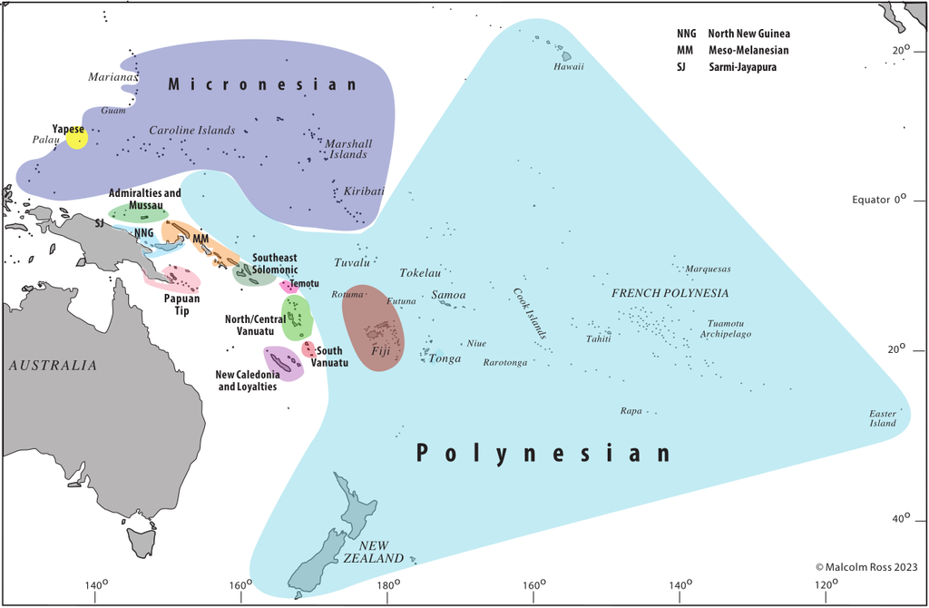

**Map 1.4:** Groups of Oceanic languages used in cognate sets

Lynch’s research on Southern Oceanic (§1.4.3.2) renders the NCV group mildly anomalous, although there is no doubt that it reflects an integrated dialect network. There are a number of etyma whose reflexes are confined to North and Central Vanuatu, and so we continue to include ‘Proto North/Central Vanuatu’ reconstructions. These perhaps represent a Southern Oceanic term that has been lost in southern Vanuatu and New Caledonia. Where the distribution of reflexes requires it, the chapters in this volume include reconstructions for PROc and for PSOc. Etyma with these distributions were attributed to PEOc in volumes 1 and 2, but the distributions are transparent, thanks to the presence of the group labels in cognate sets (cf §1.4.4.2).

In the interests of space we do not give the history of the reconstructions themselves, as this would often require commentary on the modifications made by others and by us, and on why we have made them. Where a reconstruction is not new, we have tried to give its earliest source, e.g. ‘Blust 1987’ above, but this is difficult when earlier reconstructions differ in form and meaning and when their sources are not reported.

In general, the contributions to these volumes are concerned with items reconstructable in POc, PWOc, PEOc, PROc and occasionally Proto New Guinea Oceanic (PNGOc). Etyma for PWOc, PNGOc and PEOc are reconstructed because these may well also be POc etyma for which known reflexes are not well distributed (see discussion in §1.4.4). Reconstructions for lower-order interstages are decreasingly likely to reflect POc etyma and may be the results of cultural change as Oceanic speakers moved further out into the Pacific.

Contributors to these volumes have usually not made fresh reconstructions at interstages superordinate to POc. What they have done, however, is to cite other scholars’ reconstructions for higher-order interstages, as these represent a summary of the non-Oceanic evidence in support of a given POc reconstruction. These interstages are shown in Figure 1.5.

Sometimes non-Oceanic evidence has been found to support a POc reconstruction where no reconstruction at a higher-level interstage has previously been made. In this case a new higher-order reconstruction is made, and the non-Oceanic evidence is given in a footnote.

Whilst we have tried to use the internal organisation of the lexicons of Oceanic languages themselves as a guide in setting the boundaries of each terminology, we have inevitably taken decisions which differ from those that others might have made. There are, obviously, overlaps and connections between various semantic domains and therefore between the contributions here. We have done our best to provide cross- references, but we have sometimes duplicated information rather than ask the reader repeatedly to look elsewhere in the book. Indexes at the end of each volume and in the final volume are intended to make it easier to use the volumes collectively as a work of reference.

### 5.2. Data

Data sources are listed in Appendix A.

For some reconstructed etyma only a representative sample of reflexes is given. We have endeavoured to ensure, however, that in each case this sample not only is geographically and genealogically representative, but also provides evidence to justify the reconstruction’s shape and gloss. Where only a few reflexes are known to us, this is usually noted.

Although there are accepted or standard orthographies for a number of the languages from which data are cited here, all data are transcribed as far as possible into a standard phonemic orthography based on that used by Ross (1988:3–4) in order to facilitate comparison.[^21] This means, for example, that the *j* of the German-based orthographies of Yabem and Gedaged becomes *y*, Yabem *c* becomes *ʔ*, Gedaged *z* becomes *ɬ* and so on; the *ng* of English-based orthographies becomes *ŋ*; and Fijian *g*, *q* and *c* become *ŋ*, *g* and *ð* respectively.

The following symbols have more or less their usual IPA (Interenational Phonetic Association) values: *ð*, *ɢ*, *ɣ*, *h*, *k*, *l*, *ʟ*, *ɬ*, *ʎ*, *m*, *n*, *ŋ*, *ñ*, *p*, *q*, *χ*, *ɾ*, *r*, *s*, *t*, *w*, *x*, *z*, *ʔ*, *a*, *æ*, *e*, *ɛ*, *ə*, *i*, *ɨ*, *o*, *œ*, *ɔ*, *ʌ*, *u*, *ɯ*. As far as possible, however, our orthography is phonemic and does not show allophonic variation, so that there are instances where a symbol does not have its usual phonetic value. For example, Wayan Fijian *k* is a voiceless stop word-initially but [k] is in free or stylistic variation with [ɣ] word-medially. The voiced stops *b*, *d*, *g* and the voiced bilabial trill *ʙ* are prenasalised in some languages, but prenasalisation is not written unless it is phonemically distinctive. Where a language has just one rhotic, we usually write *r*, despite the fact that that rhotic is sometimes a flap. Other orthographic symbols (with values in IPA) are:

| *f* | [ɸ, f] | voiceless bilabial or (less often) labio-dental fricative |
| --- | --- | --- |
| *v* | [β, v] | voiced bilabial or (less often) labio-dental fricative |
| *c* | [ts], [ʧ] | voiceless alveolar or palatal affricate |
| *j* | [ʣ], [ʤ] | voiced alveolar or palatal affricate |
| *y* | [j] | palatal glide |
| *dr* | [ⁿr] | prenasalised voiced alveolar trill (as in Fijian) |
| *ö* | [ø] | rounded mid front vowel |
| *ü* | [y] | rounded high front vowel |

Other superscripts and diacritics are as follows:

- contrastive long vowels are represented by a macron, e.g. *ā*;
- contrastive vowel nasalisation is represented by a tilde, e.g. *ã*;
- high and low tone are represented respectively by an acute and a grave accent, e.g. *é*, *è*;[^22]
- labialisation is marked by a superscript w, e.g. *pʷ*;
- velarisation is marked by a superscript ɯ, e.g. *pᵚ*;
- contrastive aspiration is marked by a superscript h, e.g. *pʰ*;
- contrastive devoicing is marked by a small circle beneath, e.g. *n̥*;
- apicolabials are represented by the corresponding apical symbol and the linguolabial diacritic (the ‘seagull’), e.g. *t̼*;
- retroflexes are represented by the corresponding apical symbol with a dot beneath, e.g. *ṛ*.

Except for inflexional morphemes, non-cognate portions of reflexes, i.e. derivational morphemes and non-cognate parts of compounds, are shown in parentheses (…). Where an inflexional morpheme is an affix or clitic and can readily be omitted, its omission is indicated by a hyphen at the beginning or end of the base. This applies particularly to possessor suffixes on directly possessed nouns (see §2.2). Where an inflexional morpheme cannot readily be omitted, it is separated from its base by a hyphen. This may happen because of complicated morphophonemics or because the morpheme is always present, like the attributive *-n* in some NNG and Admiralties languages and prefixed reflexes of the POc article *na in scattered languages. When a reflex is itself polymorphemic (i.e. the morphemes reflect morphemes present in the reconstructed etymon) or contains a reduplication, the morphemes or reduplicates are also separated by a hyphen.

Languages from which data are cited in this volume are listed in Appendix B in their subgroups or linkages, together with an index allowing the reader to find the subgroup to which a given language belongs. Appendix B also includes alternative language names. The difficulty of deciding where the borderline between dialect and language lies, combined with the fact that these volumes contain work by a number of contributors, has resulted in some inconsistency in the way dialects are labelled in cognate sets. Some occur in the form ‘Lukep (Pono)’, i.e. the Pono dialect of the Lukep language, whilst others are represented simply by the dialect name, e.g. Iduna, noted in Appendix B as ‘Iduna (= dialect of Bwaidoga)’.

### 5.3. Conventions used in representing reconstructions

Reconstructions are marked with an asterisk, e.g. *Rumaq ‘dwelling house’, in keeping with the standard convention in historical linguistics. POc reconstructions, and also PWOc and PNGOc reconstructions, are given in the orthography of §1.7. For reconstructions at higher-order interstages the orthographies are those used by Blust in his various publications and theACD. Reconstructions at lower-order interstages are given in the standard orthography adopted for data (§4.2). Geraghty’s (1986) PCP orthography, for example, is based on Standard Fijian spelling, and is converted into our standard orthography in the same way as Fijian spelling is. In practice, this means that the orthographies for PEOc, PROc and PCP are the same as for POc, except that a distinction between *p and *v is recognised and *R is generally absent from PCP.[^23] Biggs and Clark’s PPn reconstructions are in any case written in an orthography identical to our standard. Bracketing and segmentation conventions in protoforms are shown in Table 1.1.

PMP final consonants are usually retained in POc in absolute word-final position. In many cases decisive evidence for retention or loss can be found in those Oceanic languages that usually retain final consonants. However, there are some cases where it is uncertain whether POc kept a PMP final, as when a PMP etymon is not attested in an Oceanic language that consistently retains POc final consonants. An example is *-d in PMP *palahud ‘go down to the sea or coast’, a term reflected in Oceanic only inlanguages that regularly lose POc final consonants. In such cases the consonant is reconstructed in parentheses, e.g. POc *palau(r) ‘go to sea, make a sea voyage’.

**Table 1.1.** Bracketing and segmentation conventions in protoforms

| (x) | it cannot be determined whether x was present |
| --- | --- |
| (x,y) | either x or y was present |
| [x] | the item is reconstructable in two forms, one with and one without x |
| [x,y] | the item is reconstructable in two forms, one with x and one with y |
| x-y | x and y are separate morphemes |
| x- | x takes an enclitic or a suffix |
| ⟨x⟩ | x is an infix |

In presenting words that display anomalies of form, it is often necessary to posit an expected form. For example, in §14.6.5.1, the Banoni term *raus* ‘100’ is accompanied by the note “metathesis of †*rasu*”, i.e. ‘metathesis of expected *rasu*’. In this volume we use a less widely employed convention and mark expected forms with a dagger, to distinguish an expected form both from reconstructions and real data.[^24] Sometimes we need to refer to a reconstructed form that one would expect as the regular reflex of an established POc etymon, but which does not occur because an irregular sound change has occurred. In such cases the dagger and asterisk conventions are used together. For example, in vol.5:99, we reconstruct PNCV *kaRo ‘vine, rope; vein’. It is descended, however, from POc *waRo(c) ‘vine, creeper; string, rope; vein, tendon’, and the expected PNCV form, referred to in our discussion there, would be †*waRo. The dagger marks it as expected but unattested.

When historical linguists compile cognate sets they commonly retain word for word the glosses given in the sources from which the items are taken. However, again in the interests of standardisation, we have often reworded (and sometimes abbreviated) the glosses of our sources, while preserving the meaning. Where glosses were in a language other than English we have translated them. In the interests of space and legibility, and because data often have multiple sources, we have given the source of a reflex only when it is not included in the listings in Appendix A.

Sometimes our authors use the convention of providing no gloss beside the items in a cognate set whose gloss is identical to that of the POc (or other lower-order) reconstruction at the head of the set, i.e. the reconstruction which they reflect. Where necessary, we use ‘(N)’ to indicate that a gloss is a noun, and ‘(V)’, ‘(VI)’, ‘(VT)’ or ‘(VSt)’ to indicate that it is a verb, intransitive verb, transitive verb or stative verb. Because in many environments transitive verbs were regularly formed from the intransitive stem by adding the suffix *-i- (vol.5:24), in many cases the intransitive and transitive verbs are simply shown in sequence, e.g. POc *qalo(p), *qalop-i- ‘beckon with the palm downward, wave’. In such cases, the first verb is always intransitive, the second (in *-i-) transitive.

Within glosses we use the conventional abbreviations ‘k.o.’ (as in ‘k.o. yam’) for ‘kind of’, ‘s.o.’ for ‘someone’ and ‘s.t.’ for ‘something’.

**Table 1.2.** POc consonants used in reconstructions in the six volumes of this work.

|  | labialised bilabial | bilabial | dental | alveolar | palatal | velar | labialised velar | uvular |
| --- | --- | --- | --- | --- | --- | --- | --- | --- |
| stop voiceless | *pʷ | *p | *t |  | *c | *k | *kʷ | *q |
| stop voiced | *bʷ | *b |  | *d | *j | *g |  |  |
| trill |  |  |  | *r |  |  |  |  |
| prenasalised trill |  |  |  | *dr |  |  |  |  |
| nasal | *mʷ | *m |  | *n | *ñ | *ŋ |  |  |
| fricative |  |  |  | *s |  |  |  |  |
| lateral |  |  |  | *l |  |  |  |  |
| approximant | *w |  |  |  | *y |  |  |  |

## 6. Proto Oceanic bound morphology

Proto Oceanic bound morphology is not discussed in this volume, other than in §2.2, as the use of possessor suffixes with inalienably possessed nouns plays a role in reconstructions in chapter 2.

An account of aspects of POc morphology, especially verbal derivational morphology, is given in vol.5:21–26, where it is followed by some comments on the fossilisation of earlier morphology in POc forms (vol.5:26–30).

## 7. Proto Oceanic phonology and orthography

Work based on the sound correspondences of both Oceanic and non-Oceanic languages has resulted in the reconstructed paradigm of POc consonants shown in Table 1.2. A number of Oceanic (and non-Oceanic) languages attest to the facts that *t was dental, *d alveolar. This is significant in the prehistory of POc discussed below (§1.8.2.3). The POc vowels that occur in our reconstructions are *i, *e, *a, *o, *u.

In the light of recent work it is likely that both the consonant and vowel sets require some revision. We return to this in sections 1.8.2 and 1.8.3.

Lynch (2000a) concludes that POc stress fell on the penultimate mora. Each vowel counted as one mora, and so did the final consonant if there was one. Hence the stress of a word that ended in a vowel like *ku̱tu̱ ‘head louse’ (a mora is indicated by an underscore) fell on its penultimate syllable: *kútu. The stress of a word that had a final consonant, like *ma̱nu̱ḵ ‘bird’, fell on the final syllable: *manúk. Note that an inalienably possessed noun (§2.2) took a possessor suffix, and that this must have resulted in stress shift: *máta ‘eye’, but *matá-gu ‘my eye’. Inalienably possessed nouns are marked with a final hyphen in our reconstructions: *mata- ‘eye’.

**Table 1.3.** POc orthographies after Grace (1969) and Ross (1988)

| Grace | oral grade | *p | — | *t | *d/*r | *s |  | *j | *k | — |
| --- | --- | --- | --- | --- | --- | --- | --- | --- | --- | --- |
| Ross | oral grade | *p | *pʷ | *t | *r | *s |  | *c | *k | *kʷ |
| Grace | nasal grade | *mp | *ŋp/*mpw | *nt | *nd |  | *nj |  | *ŋk |  |
| Ross | nasal grade | *b | *bʷ | *d | *dr/*nr |  | *j |  | *g |  |

| Grace | *m | *ŋm/*mw | *n | *ñ | *ŋ | *w | *y | *l | *q | *R | *i | *e | *a | *o | *u |
| --- | --- | --- | --- | --- | --- | --- | --- | --- | --- | --- | --- | --- | --- | --- | --- |
| Ross | *m | *mʷ | *n | *ñ | *ŋ | *w | *y | *l | *q | *R | *i | *e | *a | *o | *u |

Table 1.3 shows two POc orthographies. The first was established by Biggs (1965) for PEOc and applied to POc by Grace (1969). It was used with a number of variants, separated by a slash in Table 1.3. The second orthography, used here and in the POc reconstructions in these volumes is from Ross (1988, 1989b), with the addition of *pʷ (introduced without comment by Blust 1984) and *kʷ (Ross 2011). The terms “oral grade” and “nasal grade” belong to the terminology of Oceanic historical phonology (§1.8.1 and §1.8.2).

## 8. The phonological prehistory of Proto Oceanic

In section 1 we expressed the hope that the material would be a rich source of data for historical linguistics. Section 1.8.2 and its subsections, along with §1.9, report on research based on the POc reconstructions in volumes 1–5. First, however, we recapitulate the currently conventional view of POc phonology.

The widely accepted hypothesis about the provenance of Proto Oceanic is shown in Figure 1.5. It is due to Robert Blust, originally presented in Blust (1977b) and repeated with modifications and accumulated supporting evidence in subsequent publications (Blust 1978a, 1982, 1983–84b, 1993, 2009b). New research based on the reconstructions in volumes 1–5 and summarised in §1.8.2 and its subsections, §1.9.1 proposes that this hypothesis—we will call it the “accepted hypothesis”—should be retired. The fresh research confronts us with the need to reassess the part of the tree that is headed by Proto Central/Eastern Malayo-Polynesian. This leads to a re-evaluation in §1.9.3 of where Proto Oceanic came from.

The conventions used in Figure 1.5 are those outlined in §1.4.3.1 for Figure 1.1. Thus *Formosan languages* in Figure 1.5 indicates a collection of languages descended (along with PMP) from PAn (Blust 1999). They are spoken in Taiwan, but do not form a subgroup. There was no ’“Proto Formosan”, as Formosan languages and language groups are all descended directly from PAn. Despite references to “Proto Western Malayo-Polynesian”, *Western Malayo-Polynesian languages* have never been seriously considered a subgroup of Austronesian (Ross 1995b; Adelaar 2004). Smith (2017) provides a set of hypotheses about the groups that make up WMP.[^25] Their common ancestor is PMP. Recent years have seen renewed research into the Central Malayo-Polynesian languages and those of South Halmahera/West New Guinea, and we turn to this in §1.9.

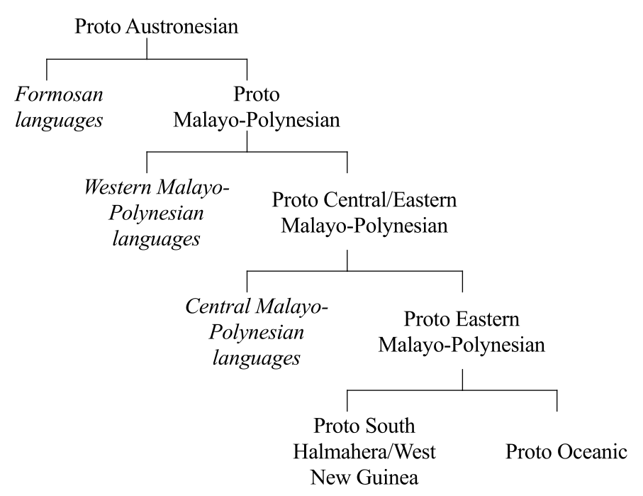

**Figure 1.5:** Schematic diagram showing the widely accepted genealogy of the Austronesian family

### 8.1. The Proto Austronesian and Proto Malayo-Polynesian antecedents of Proto Oceanic phonology

First, though, it is noteworthy that much research on the prehistory of the POc lexicon has focussed on phonological changes that occurred between PMP and POc. This is because PMP and POc are protolanguages clearly defined by shared innovations, the bedrock of the linguistic comparative method, whereas Blust’s two proposed interstages, PCEMP and PEMP (Blust 1978), are only weakly defined.

We give here a conventional account of POc innovations, before revising this history in §1.8.2 in the light of research based on the reconstructions in volumes 1–5.

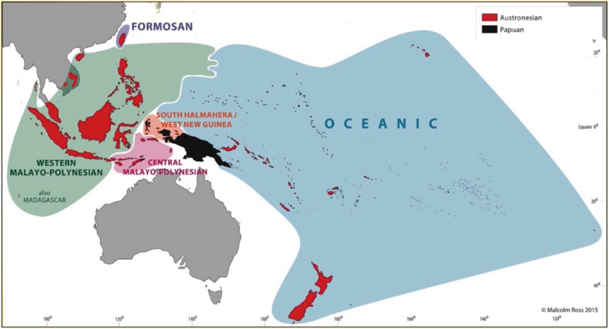

**Map 1.5:** The Austronesian language family and the major subgroups according to the standard hypothesis

**Table 1.4.** Correspondences between PMP and POc protophonemes as currently understood. Shadings are explained in §1.8.2

| PAn |  | *p, *b | — | *t, *C | *d, *r | *s, *z | *j | *k, *g | — |
| --- | --- | --- | --- | --- | --- | --- | --- | --- | --- |
| PMP |  | *p, *b | — | *t | *d, *r | *s, *z | *j | *k, *g | — |
| POc | oral grade: | *p | *pʷ | *t | *r | *s | *c | *k | *kʷ |
|  | nasal grade: | *b | *bʷ | *d | *dr | *j |  | *g | — |

| PAn | *m | — | *n, *-L(-) | *ñ | *ŋ | *w | *y | *l, *L- | *q | **R* | *S |
| --- | --- | --- | --- | --- | --- | --- | --- | --- | --- | --- | --- |
| PMP | *m | — | *n | *ñ | *ŋ | *w | *y | *l | *q | **R* | *h |
| POc | *m | *mʷ | *n | *ñ | *ŋ | *w | *y | *l | *q | **R* | *∅ |

| PAn/PMP | *i, *-uy(-) | *e [ə], *-aw | *-ay | *a | *u |
| --- | --- | --- | --- | --- | --- |
| POc | *i | *o | *e | *a | *u |

The Oceanic subgroup is defined by a set of shared innovations relative to PMP. It was on the basis of some of these that Dempwolff (1927, 1937) first recognised his *Urmelanesisch* (‘Proto Melanesian’) as a major Austronesian subgroup. In the 1937 work he also recognised that Polynesian languages shared the innovations of *Urmelanesisch*, and so the concept of an Oceanic subgroup entered the literature. However, naming it took a while. Grace (1955) defined the borders of the new subgroup and called it “Eastern Malayo-Polynesian”.[^26]

Meanwhile, Milke (1958) made frequent reference to *ozeanisch-austronesische Sprachen* (‘Oceanic-Austronesian languages’) and in 1961 finally adopted the terms *ozeanische Sprachen* and *proto-Ozeanisch* (‘Oceanic languages’, ‘Proto Oceanic’), which were soon adopted by his colleagues.

Correspondences between PAn, PMP and POc protophonemes are shown in Table 1.4. PAn protophonemes are shown for reference, as the volumes of this work cite PAn reconstructions fairly often.

Certain POc innovations exclusive to Oceanic languages are immediately visible in the form of a number of mergers and splits, highlighted in colour in Table 1.4.

1. The PMP voiced/voiceless pairs *p/*b, *k/*g and *s/*z and the PMP pair *d/*r each merged respectively as *p, *k, *s and *r in an interstage that we label ‘Proto X’
2. Proto X *p, *k, *s and *r then split to give POc “oral-grade” *p, *k, *s and *r and “nasal-grade” *b, *g, *j and *dr (the “grade” terms are explained in §1.8.2). Although *t did not participate in the merger in (a), *t did participate in the split, with POc oral-grade *t and nasal-grade *d.
3. A small complication is that PMP *j did not participate in the merger in (a), but did participate in the split in (b), its POc nasal grade merging with that of *s.

Ozanne-Rivierre (1992) suggests that the corresponding *t/*d merger was hindered by the mismatch in point of articulation between dental *t and alveolar *d, a mismatch attested in many non-Oceanic Austronesian languages.

Table 1.5 is a corrected and expanded version of the table in Blust (2013:599) showing examples of PMP reconstructions and their POc continuations. It illustrates the combined effect of (a) and (b): each of the PMP pairs *p/*b, *k/*g, *s/*z and *d/*r first merged and then split. The set of changes in (a) and (b) alone is unusual enough to be strong evidence for the integrity of the Oceanic subgroup.

**Table 1.5.** Examples of PMP reconstructions and their POc continuations showing the effects of the mergers and splits giving rise to POc consonant grade

| segment | PMP | POc | grade | gloss |
| --- | --- | --- | --- | --- |
| *p- | *pitu* | *pitu* | oral | seven |
| *p- | *punay* | *bune* | nasal | pigeon |
| *-p- | *hapuy* | *api* | oral | fire |
| *-mp- | *t-umpu* | *tubu* | nasal | ancestor |
| *b- | *bulan* | *pulan* | oral | moon |
| *b- | *beRek* | *boRok* | nasal | pig |
| *-b- | *qabu* | *qapu* | oral | ashes |
| *-mb- | *ambit* | *abit* | nasal | hold in hand |
| *t- | *taqun* | *taqun* | oral | year |
| *t- | — | — | (nasal) | — |
| *-t- | *qutin* | *qutin* | oral | penis |
| *-nt- | *-nta* | *-da* | nasal | P:1INC.PL |
| *-nt- | *punti* | *pudi* | nasal | banana |
| *d- | *duha* | *rua* | oral | two |
| *d- | *daRaq* | *draRaq* | nasal | fresh water |
| *-d- | *kuden* | *kuron* | oral | cooking pot |
| *-nd- | *pandan* | *padran* | nasal | pandanus |
| *s-s- | *susu* | *susu* | oral | breast |
| *s- | *siRi* | *jiRi* | nasal | a shrub: *Cordyline* |
| *-s- | *ŋusuq* | *ŋuju-* | nasal | lips, snout, beak |
| *z- | *zaqat* | *saqat* | oral | bad |
| *-z- | *quzan* | *qusan* | oral | rain |
| *z- | *zalan* | *jalan* | nasal | path, road |
| *-z- | *tazim* | *tajim* | nasal | sharp |
| *k- | *kali* | *kali* | oral | dig |
| *k- | *kumuR* | *gumu* | nasal | gargle, rinse mouth |
| *-k- | *seka* | *soka* | oral | pierce, stab |
| *-ŋk- | *laŋkaw* | *lago* | nasal | tall, long |
| *g- | *gaway* | *kawe* | oral | octopus tentacle |
| *g- | *gemgem* | *gogom* | nasal | hold in fist |
| *-g- | *liget* | *likot* | oral | turn, rotate |
| *-g- | — | — | (nasal) | — |

Another set of innovations is the introduction of the labiovelars *pʷ, *bʷ, *mʷ and *kʷ into Proto Oceanic (Blust 1981a; Lynch 2002e; Ross 2011). Many items containing a labiovelar lack non-Oceanic cognates, and some, at least, must have been borrowed into POc from neighbouring Papuan languages. For example, *mʷapo(q) ‘taro’ was apparently borrowed by POc speakers as they copied taro-growing techniques from Papuan speakers (vol.3,267). In some inherited items a labial became a labiovelar next to a round vowel, but it is not clear whether the labiovelar actually occurred in POc. Thus a number of Oceanic languages reflect *tamʷata ‘man, husband’, derived from *tau ‘body, person’ + *mataq ‘unripe, immature, young’, but we cannot be sure whether *tamʷata or *taumata(q) was the POc form (vol.5:43–44).

Collectively, innovations affecting the vowels are also exclusive to Oceanic, although individually each of them occurs in various non-Oceanic languages:

1. PMP *e, phonetically [ə], became POc *o.
2. PMP word-final diphthongs *-uy(-), *-aw and *-ay were simplified to POc *-i, *-o and *-e respectively, the first two thereby merging with plain vowels.[^27]

A further innovation that has come to light during work on these volumes concerns certain PMP trisyllabic roots with *-e- (*[ə]) as the nucleus of their penultimate syllable. These trisyllables lost *-e- in POc, along with one consonant of the resulting consonant cluster:

| PMP *biseqak | POc *pisa(k)~*pisak-i- ‘split’ (vol.1:261) |
| --- | --- |
| PMP *ma-udehi | POc *muri ‘be behind’ (vol.2:251) |
| PMP *tuqelan | POc *tuqan ‘bone’ (vol.5:85) |
| PMP *baReqaŋ | POc *paRa(ŋ) ‘molar tooth’ (vol.5:133), |
| PMP *buteliR | POc *putiR ‘wart’ (vol.5:344). |
| PMP *buqeni | POc *puni ‘ringworm, *Tinea imbricata*’ (vol.5:346) |
| PMP *ma-heyaq | POc *maya(q) ‘shy, embarrassed; ashamed’ (vol.5:585). |

The conditioning of this change remains unclear, as it did not affect the etyma below:

| PMP *maqesak | POc *maosak ‘ripe, cooked’ (vol.1:157), |
| --- | --- |
| PMP *baqeRu | POc *paqoRu ‘new’ (vol.2:203), |
| PMP *qateluR | POc *qatoluR ‘egg’ (vol.4:278) |
| PMP *qulej-an | POc *quloc-a(n) ‘maggoty’ (vol.4:415). |

PMP *qalejaw/POc *qaco ‘daylight, sun’ (vol.2,153–155) appears exceptionally to have lost the first consonant of the cluster, but there is evidence that a PAn variant *qajaw was ancestral to POc *qaco.

### 8.2. Reinterpreting the origins and distribution of POc oral- and nasal-grade consonants

This section presents a revision of the history sketched in §1.8.1, as promised there.

Figure 1.6 diagrams three accounts of the history of POc *p and *b. In the first two accounts ‘(N)’, “nasal grade”, implies that POc *b reflected an earlier nasal + obstruent sequence (*mp, *mb) and was perhaps prenasalised (POc *[ᵐb]). The terms “oral grade” and “nasal grade” were coined by Grace (1959:27) to refer to the pairs of POc obstruents that had been recognised by Dempwolff (1927).

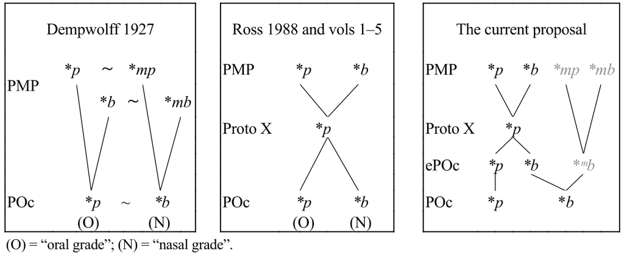

**Figure 1.6:** Three analyses of the phonological history of POc *p and *b

Dempwolff inferred that PMP *p and *b, for example, merged as POc *p, while PMP *mp and *mb merged as POc *b.[^28] He made parallel assumptions about PMP *k/*g versus PMP *ŋk/*ŋg, and PMP *s/*z/*j versus PMP *ns/*nz/*nj.[^29] He also assumed that, e.g., PMP *p and *mp, or *b and *mb, were in free variation and that they became fossilised randomly in each Oceanic daughter-language, such that a word might begin with a reflex of *p in one daughter-language but a reflex of *mp in another.

Despite the obvious improbability of this assumption and the frequent discussions of consonant grade, reviewed by Grace (1990), the randomness assumption was maintained in some form until the publication of Ross (1988).[^30] The latter found that in the vast majority of POc etyma with one or more “graded” consonants, the grade of each consonant can be reconstructed unambiguously because its Oceanic reflexes agree in grade, a finding supported by the cognate sets in the present work. The illusion of randomness had two sources. First, although Milke (1968) had correctly identified POc *j (his *nj) as the nasal-grade consonant paired with oral-grade *s, most scholars assumed that various lenited reflexes of *s reflected the nasal grade, so that the pair of *s grades seemed almost chaotic (Ross 1988:71–93; 1989b). Second, various regular local processes such as Admiralties secondary nasal grade (Ross 1988:337–341) and Eastern Fijian apical prenasalisation (Geraghty 1983:74–96) had masked consonant grade in some languages.

The fact that consonant grade can be reconstructed without ambiguity in most POc etyma largely rids POc of Dempwolff’s posited randomness, but, as the middle panel in Figure 1.6 indicates, PMP *p and *b must have merged as Proto X *p, which then split into POc *p and *b. Similar processes applied to PMP *k/*g and *s/*z/*j. This is the position adopted in the introductions to volumes 1 to 5 of this work. Ross (1988) retained the assumption that the POc voiced obstruents were “nasal grade”, i.e. reflected nasal + obstruent sequences. He attempted unsatisfactorily to explain the splits as the effects of derivational morphology (Reid 2000).

This still leaves two questions about the origin of POc consonant grade unanswered:

1. How did the POc splits come about?
2. Do POc “nasal-grade” consonants have a nasal origin?

As a result of new research based on the POc reconstructions in volumes 1–5, we have a partial answer to (a) and a definitive answer to (b), shown in the righthand panel of Figure 1.6. Following Proto X (§1.8.1), this panel shows two further interstages, “ePOc” and POc. “POc” denotes the language reconstructed in these volumes, equated with its state immediately before its break-up into daughter-languages (Pawley 2008); and “ePOc” denotes “early POc”, a stage sometime before POc, but after its speakers settled in the Bismarck Archipelago.

Comparing reconstructions in previous volumes with their ancestral PMP forms in the acd, we find that ePOc had three grades of obstruent: voiceless, voiced and prenasalised. Its voiceless obstruents are Grace’s oral-grade segments, but a majority of his “nasal-grade” segments reflect plain voiced obstruents. The prenasalised obstruents are true nasal-grade obstruents, reflecting inherited nasal + obstruent clusters. They may be inherited from PMP or from a more recent ancestor. This is the situation depicted in the righthand diagram of Figure 1.6, where the grey of the prenasalised obstruents indicates their rarity.

#### 8.2.1. The POc voiceless and voiced obstruents

Our database of POc reconstructions from volumes 1–5, along with their PMP ancestral forms (drawn directly from the ACD), contains 729 etyma.[^31] In total these reconstructions contain 429 initial and medial instances of the the PMP obstruents listed in the leftmost column of Table 1.6. The columns headed ‘> POc’ show the voiceless and voiced outcomes of the PMP phonemes (prenasalised ePOc outcomes are discussed in the next subsection). To the right of each POc obstruent in Table 1.6 are shown its number of instances as an absolute figure and as a percentage of the PMP obstruent in the leftmost column.

**Table 1.6.** Instances of PMP obstruents and their POc voiceless and voiced reflexes

|  |  | POc voiceless reflexes |  |  | POc voiced reflexes |  |  |
| --- | --- | --- | --- | --- | --- | --- | --- |
| PMP | total | > POc | total | % | > POc | total | % |
| *p | 94 | *p | 82 | 87.2 | *b | 12 | 12.8 |
| *b | 128 | *p | 101 | 78.9 | *b | 27 | 21.1 |
| *s | 75 | *s | 69 | 92.0 | *j | 6 | 8.0 |
| *z | 14 | *s | 10 | 71.4 | *j | 4 | 28.6 |
| *-j- | 17 | *-c- | 13 | 76.5 | *-j- | 4 | 23.5 |
| *k | 93 | *k | 91 | 97.8 | *g | 2 | 2.2 |
| *g | 8 | *k | 8 | 100.0 | *(*g)* | 0 |  |
| *C | 429 | *C<sub>voiceless</sub> | 374 | 87.2 | *C<sub>voiced</sub> | 55 | 12.8 |

The table tells a somewhat unexpected story. Only 13 per cent of the instances of PMP obstruents end up as POc voiced obstruents. It is also unclear whether Proto X *k actually split into POc *k and *g. PMP *p/*b, *k/*g and *s/*z each evidently merged as the Proto X phonemes *p, *k and *s. Proto X *p and *s then split into POc *p/*b and *s/*j respectively. If Proto X *k split, the outcome is inconsequential. Only eight instances of PMP *g occur in the first place, against 93 instances of PMP *k. No instances of PMP *g end up as POc *g, and just two instances of PMP *k do so.

As noted above, PMP *t (129 instances) did not participate in these processes and is always reflected as POc *t. PMP *r, with 27 instances, is omitted from the table because all its POc outcomes are *r. PMP *d probably underwent a split, but the split was in prenasalisation, not in voicing (§1.8.2.3).

#### 8.2.2. The POc prenasalised obstruents

POc reflexes of PMP nasal + obstruent clusters are omitted from Table 1.6, as the numbers of reflexes are generally few and would skew the table’s percentages. Instead, POc reflexes of these PMP clusters are shown separately in Table 1.7. The instances are all in etyma drawn from theACD(and found among the POc reconstructions in volumes 1-5). Instances of nasal + obstruent clusters that arose sometime between the break-up of PMP and the break-up of POc are not shown in Table 1.7, as they would obscure the relationship between PMP and POc.

PMP nasal + obstruent clusters are reflected as POc unitary phonemes. In fact their POc outcomes appear to be the same as those of PMP voiceless and voiced obstruents in Table 1.6, but we argue below in §1.8.2.4 that this is incorrect, and reconstruct ePOc prenasalised rather than voiced outcomes in Table 1.7. The PMP clusters are shown in the table as *-Np-/*-Nb- etc as there are instances where the cluster is not homorganic. Some are the result of reduplication of a monosyllable, e.g., PAn/PMP *demdem ‘dark, gloomy, overcast’, attested with *-md-* in Formosan and many Philippine reflexes (ACD), but becoming *dendem at some intermediate interstage and thence POc *rodrom (vol.2:308). POc *-dr- is a unitary phoneme reflecting earlier *-nd- (PCEMP *-nd- according to Blust 1977a).

**Table 1.7.** Instances of PMP nasal + obstruent clusters and their POc reflexes

[output not shown]

Blust (2022) shows that homorganic nasal + obstruent clusters were present in PMP, but were rare, as Table 1.7 confirms. Their very rarity has meant that scholars have paid little attention to them as a discrete category (Collins 1983 and Mills 1991 are exceptions). Further, reconstructions in theACDfor PCEMP, the next node below PMP in Blust’s tree (Figure 1.5), show little sign of acquiring nasal + obstruent clusters, other than those resulting from reduplications.

TheACDincludes just four PCEMP items which contain nasal + obstruent clusters and have no cognates outside CEMP. They are:[^32]

| PCEMP *tambu | POc *tabu | ‘forbidden, taboo’ (this volume, chapter 10) |
| --- | --- | --- |
| PCEMP *kandoRa | POc *kadroRa | ‘cuscus’ (vol.4:225) |
| PCEMP *waŋka | POc *waga | ‘canoe’ (vol.1:178) |
| PCEMP *mans[ə,a]r | POc *mʷaja(r,R) | ‘bandicoot’ (vol.4:228) |

Table 1.5 illustrates the fact that voiced and prenasalised obstruents are conventionally treated as a single—nasal-grade—POc category, as their reflexes in almost all Oceanic languages are identical. Of the POc medial nasal-grade items in that table, those reflecting PMP *t-umpu, *ambit, *-nta, *punti, *pandan and *laŋkaw ancestrally had a nasal + obstruent cluster, while those reflecting *ŋusuq and *tazim did not. Only 22 POc “nasal-grade” consonants in our database were descended from nasal + obstruent clusters (Table 1.7). Fifty-five reflect PMP plain voiceless or voiced obstruents (Table 1.6).

Table 1.6 allows us finally to understand where POc voiced initial consonants came from. Ever since Dempwolff (1927) the default assumption has been that they reflected nasal + obstruent clusters, with scholars trying—and failing—to find grounds to reconstruct ancestral initial nasal + obstruent clusters (Milner 1965; Ross 1988:39–43; Grace 1990; Reid 2000). The reason for the failure is now evident: POc initial “nasal- grade” obstruents actually reflect PMP plain voiceless or voiced obstruents (Table 1.6). PMP nasal + obstruent clusters were always medial (Table 1.7). They never occurred initially.

#### 8.2.3. PMP *t, *d and *r

We have seen that PMP *t and *d did not form a voiceless/voiced pair, as they had different points of articulation.

With regard to PMP *t, there is a mismatch between the findings reported in Table 1.6 and Table 1.7. The former reports that PMP *t did not undergo the merger-and-split sequence that affected PMP *p and *s, and therefore did not give rise to POc “nasal-grade” (voiced) reflexes. Hence PMP initial *t is never reflected as POc *d. But Table 1.7 reports three POc etyma reflecting PMP *-nt-, namely the P:1INC.PL suffix *-ⁿda (< PMP *-nta < *=ni-ta; Blust 1977b), *puⁿdi ‘banana’ (< PMP *punti) and *maⁿdala(q) ‘the morning star’ (< PMP *mantalaq-). This was the sole source of “nasal-grade” reflexes of *t, and the overall rarity of earlier nasal + obstruent sequences explains why POc has so few reflexes of *-nt-.

POc *r and *dr, outcomes of the split of PMP/Proto X *d, have conventionally been treated as one of the POc oral-/nasal-grade phoneme pairs (§1.8.2.1). Within the earlier framework this characterisation was correct, as the POc phonological contrast was evidently *[r] vs *[n(d)r].[^33] However, we have above recast the conventional POc oral-/nasal-grade pairings as voiceless/voiced pairings. But the feature that distinguishes *dr from *r is prenasalisation, not voicing, so it does not belong to this pair set.

Our database has 40 instances of PMP *d, of which 33 are reflected as POc *r and seven as POc *dr. PMP *r, with 27 instances, is omitted from Table 1.6 because all its POc outcomes are *r. At some point the *r reflexes of PMP *d and *r merged as POc *r.

#### 8.2.4. More evidence for POc prenasalised obstruents

In most Oceanic languages the proposed POc voiced (§1.8.2.1) and prenasalised (§1.8.2.2) phonemes at each point of articulation have merged. The evidence that they were once separate is based primarily on the different sources of each and on the fact that the theory accounts neatly for the relative rarity of reflexes of PMP *-nt-. Had they already merged in POc? In this section we propose that they had not, because there is evidence from five Western Oceanic languages that the distinction between voiced and prenasalised obstruents posited for ePOc was retained in POc.

We know of five Western Oceanic languages that contrast voiceless, plain voiced and prenasalised voiced obstruents. They are Mangap (now better known as Mbula), Sio, Tami, Numbami and Sudest. The only close examination of the contrasts that persist in one of these languages is Bradshaw (1978) on Numbami. The first four languages are located in the area of greatest diversity within the North New Guinea cluster, and are not especially closely related, making them possible candidates for retaining an ancient feature. Sudest is a Papuan Tip language. Contra Ross (1988:192) the immediate ancestor of Sudest and Nimowa now appears to have been the first language to break away from the rest of the early Papuan Tip family, making Sudest another candidate for ancient retentions.[^34] We refer to these five languages as the “distinction-retaining languages”.

The obstruent series in the distinction-retaining languages are:

Mangap

| *p* | *t* | *k* |
| --- | --- | --- |
| *b* | *d* | *g* |
| *ᵐb* | *ⁿd* | *ᵑg* |

Sio

| *pʷ* | *p* | *t* | *k* |
| --- | --- | --- | --- |
| *bʷ* | *b* | *d* | *g* |
| *ᵐbʷ* | *ᵐb* | *ⁿd* | *ᵑg* |

Tami

| *pʷ* | *p* | *t* | *s* | *k* | *kʷ* |
| --- | --- | --- | --- | --- | --- |
| *bʷ* | *b* | *d* | *j* | *g* | *gʷ* |
| *ᵐbʷ* | *ᵐb* | *ⁿd* | *nj* | *ᵑg* | *ᵑgʷ* |

Numbami

| *p* | *t* | *s* | *k* |
| --- | --- | --- | --- |
| *b* | *d* | *z* | *g* |
| *-ᵐb-* | *-ⁿd-* | *-ⁿz-* | *-ᵑg-* |

Sudest

| *pʷ* | *p* | *t* | *s* | *k* | *kʷ* |
| --- | --- | --- | --- | --- | --- |
| *bʷ* | *b* | *d* | *j* | *g* | *gʷ* |
| *ᵐbʷ* | *ᵐb* | *ⁿd* | *nj* | *ᵑg* | *ᵑgʷ* |

A preliminary search for cognate sets reflecting POc etyma that include prenasalised consonants reveals an interesting pattern. A small group of etyma is almost always reflected with the prenasalised consonant intact, while a larger collection of etyma is reflected unpredictably with a mixture of plain voiced and prenasalised voiced reflexes. This larger collection suggests that in these items, plain and prenasalised consonants are gradually falling together into a single category. The membership of the small group of cognate sets is significant, as its members include some sets that reflect POc etyma that on independent evidence contained prenasalised obstruents in PMP or PCEMP.

Thus Blust (1977b) reconstructs PMP possessor suffixes that were prenasalised because they consisted of the morph *ni* + pronoun. They retain their prenasalised obstruents in ePOc:

| *-ᵑgu | P:1SG | < PMP *-ŋku < *=ni-ku |
| --- | --- | --- |
| *-ⁿda | P:1INC.PL | < PMP *-nta < *=ni-ta |
| *-dra | P:3PL | < PMP *-nda < *=ni-da |

The first two of these are reflected in the distinction-retaining languages. The P:3PL suffix was replaced by PWOc *-dri.[^35] At some point prenasalisation has been copied onto this etymon.

|  | P:1SG | P:1INC.PL | P:3PL |
| --- | --- | --- | --- |
| PMP | *-ŋku | *-nta | *-nda |
| ePOc | *-ᵑgu | *-ⁿda | *-ⁿra |
| POc | *-gu | *-da | *-dra, PWOc *-dri |
| Mangap | *-ŋ* | *-ndV* | *-n* |
| Sio | *-ŋgu* | *-nda* | *-nzi* |
| Tami | *-ŋ* | *-n* | *-n* |
| Numbami | *-ŋgi* | *-ndi* | *-ndi* |
| Sudest | *-ŋgu* | *-nda* | *-nji* |

Further etyma with independent evidence of PMP or PCEMP prenasalised obstruents and reflected in the distinction-retaining languages are given below. A few comments are necessary. The blanks represent cases where, as far as we know, the etymon is not reflected in the relevant language. This pattern reflects the level of lexical replacement in Oceanic languages around the coasts of New Guinea.

|  | ‘pandanus’ | ‘sago’ | ‘canoe’ | ‘betelnut’ | ‘banana’ |
| --- | --- | --- | --- | --- | --- |
| PMP/PCEMP | *paŋdan | *R(a,u)mbia | *waŋka | *buaq | *punti |
| ePOc | *paⁿran | *Raᵐbia | *waᵑga* | *ᵐbuaq | *puⁿdi* |
| POc | *padran | *Rabia | *waga | *buaq | *pudi |
| Mangap | *pānda* | — | *wōŋgo* | *mbu* | *pin* |
| Sio | *ponda* | *rambia* | *woŋga* | — | — |
| Tami | — | *lambi* | *waŋ* | *mbu* | *pun* |
| Numbami | — | — | *waŋga* | *buwa* | *undi* |
| Sudest | — | *mbi* | *waŋga* | — | — |

PMP *paŋdan acquired its nasal + stop sequence by losing *-u- from PAn *paŋudaN, leaving no doubt that the POc form had a prenasalised consonant. The evidence for the other forms above is less pressing, but they all have so many WMP reflexes with a nasal + stop cluster that one can be confident that the PMP or PCEMP form had the cluster, which was inherited into ePOc as a prenasalised obstruent (*waŋga is PCEMP). This is true of *punti, but if the argument about PMP *-nt- in §1.8.2.3 holds, then the POc form can only be a prenasalised stop.

POc *ᵐbuaq appears to be unique in having a prenasalised initial. The story of this form is difficult to reconstruct. According to the ACD’s version, PAn *buaq continued until POc, where it split into oral-grade-initial *puaq ‘fruit (including betelnut)’ and nasal-grade-initial *buaq ‘betelnut’. The mechanism of the split is unknown, but evidence shows that it occurred earlier than POc, as it is reflected in some Wallacean languages.[^36]

These cognate sets attest to the presence of ePOc *ᵐb, *ⁿd and *ᵑg in addition to the consonants in Table 1.2. Given that this preliminary search in distinction-retaining languages was confined to the 200-word lists in the Austronesian Basic Vocabulary Database (Greenhill et al. 2008) with some small additions from single-language sources,[^37] the result is quite telling.

How do we account for the data from the distinction-retaining languages, four belonging to NNG, one to PT? More research is needed, but the account with the best fit says that they retain a distinction that was present in early POc, but lost in the vast majority of its daughter-languages. This represents drift, i.e. independent parallel innovation, probably due to the paucity of lexical items containing a prenasalised obstruent. Because almost all Oceanic languages lack the distinction between plain voiced and prenasalised voiced obstruents, researchers, including ourselves, have reconstructed POc without it. But since a few WOc languages retained the distinction at the time POc broke up, it should be reconstructed for POc.That is, “ePOc” and “POc” in the righthand panel of Figure 1.6 need to be recalibrated. “ePOc” is the real Proto Oceanic, and “POc” reflects the merger that by the time of its break-up had probably occurred in the dialects ancestral to all non-WOc languages, and in many WOc dialects too.

### 8.3. Revising the history of Proto Oceanic vowels?

Lynch (2022) argues entirely on the basis of Oceanic evidence that the POc vowel system was not the neat conventionally accepted five-vowel system shown in §1.8.1, but a system partway between the PMP four-vowel system of *i, *e [ə], *a, *u and the five-vowel system that emerged later in most Oceanic languages. We showed in §1.8.1 that in the conventional view the sources of POc vowels were as follows:

- POc *i < PMP *i, *-uy(-)
- POc *u < PMP *u
- POc *a < PMP *a
- POc *-e < PMP *-ay
- POc *o < PMP *ə, *-aw*

Lynch suggests that the POc system of non-final vowels (i.e. discounting POc *-ay and *-o from PMP *-ay and *-aw) was one of the following three:

| (A) | *i |  | *u |
| --- | --- | --- | --- |
|  |  | *ə |  |
|  |  | *a |  |

| (B) | *i |  | *u |
| --- | --- | --- | --- |
|  |  | *ə | *o |
|  |  | *a |  |

| (C) | *i |  | *u |
| --- | --- | --- | --- |
|  | *e | *ə | *o |
|  |  | *a |  |

Lynch’s revision suggests no change to the origins of high *i and *u or low *a. It is the mid vowels that changed, but he is uncertain when. His system A infers that there had been no change in the PMP system by the time POc broke up. Systems B and C both assume that PMP *ə was in the process of becoming *o when POc dispersed, and C assumes that *ə also became POc *e under certain conditioning.

## 9. Where did Proto Oceanic come from?

The conventional answer to the question, “Where did Proto Oceanic come from?”, is the accepted hypothesis in Figure 1.5. It says that POc is the sibling of PSHWNG, and the two are the only children of PEMP (Blust 1978). PEMP in its turn is a sibling of the CMP languages, and they are all children of PCEMP (Blust 1982, 1983–84b, 1993). The latter is a sibling of WMP languages and a child of PMP. To our knowledge, no scholar disputes the claim that POc is descended from PMP. However, two recent pieces of research raise the need to look more closely at the intervening stages between PMP and POc.

The first, Kamholz (2014), uses a much larger body of evidence to establish the integrity of Blust’s (1978) PSHWNG on the basis of shared innovations. Kamholz does not examine the probity of PEMP, but the innovations that define his PSHWNG are different enough from those defining POc to invite a re-examination of the PEMP hypothesis.

The other work is Grimes & Edwards’ (in prep.) analysis of available CMP data. They identify eight CMP subgroups on the basis of mostly shared phonological innovations. They find areal similarities, some of them probably consequences of one or more Papuan substrates (see also Schapper 2015; 2018), but no significant exclusively shared innovations across subgroups, and thus no evidence for a putative Proto Central Malayo-Polynesian.

Blust (1993, 2009b) views the CMP languages as a linkage on the basis of innovations that chain (§1.4.3.1) various groups together,[^38] but Grimes & Edwards find little evidence to support such an analysis. Blust’s arguments for PCEMP have evoked vigorous criticism (Donohue & Grimes 2008; Schapper 2011) and responses (Blust 2009b, 2012). The lack of evidence for Proto Central Malayo-Polynesian logically entails abandoning PCEMP as well, and this leaves a gap in the the prehistory of POc according to the accepted hypothesis.

Kamholz and Grimes & Edwards indirectly prompt a further look at two POc-related questions:

1. Are the SHWNG languages the closest relatives of Oceanic?
2. How are SHWNG and Oceanic related to CMP groups?

Our answer to (a) is, no, the SHWNG languages are probably not the closest relatives of Oceanic. Our answer to (b) is that SHWNG appears more closely related to some of the CMP groups than to Oceanic, while the relationship of Oceanic to CMP languages is ambiguous, implying that it may have branched off the Austronesian tree separately from CMP, perhaps at a node from which various CMP groups branched, or perhaps at a higher node. We can only give a summary of findings here (for more detail see Ross, in prep.).

One other answer to the question, “Where did Proto Oceanic come from?” is implicit in the literature, and it would be remiss of us not to mention it. Bellwood (2011) suggests that Lapita pottery displays a likeness to contemporaneous pottery from the Marianas Islands in Micronesia. As far as we know, the only language then spoken in the Marianas was an earlier form of Chamorro, which originated in the northern Philippines (Blust 2000a). Bellwood’s hypothesis might imply a flow of early Chamorro speakers into the Bismarck archipelago, but there is no linguistic indication of such a presence in POc or its descendants.[^39]

### 9.1. Blust (1978) on PEMP

Much of Blust (1978), the seminal work on PEMP, is devoted to demonstrating the integrity of SHWNG. Kamholz’s (2014) analysis agrees. A smaller part of Blust’s paper is devoted to PEMP, i.e. to innovations shared by SHWNG and POc. Blust offers 53 shared lexical innovations, but no shared phonological or morphosyntactic innovation

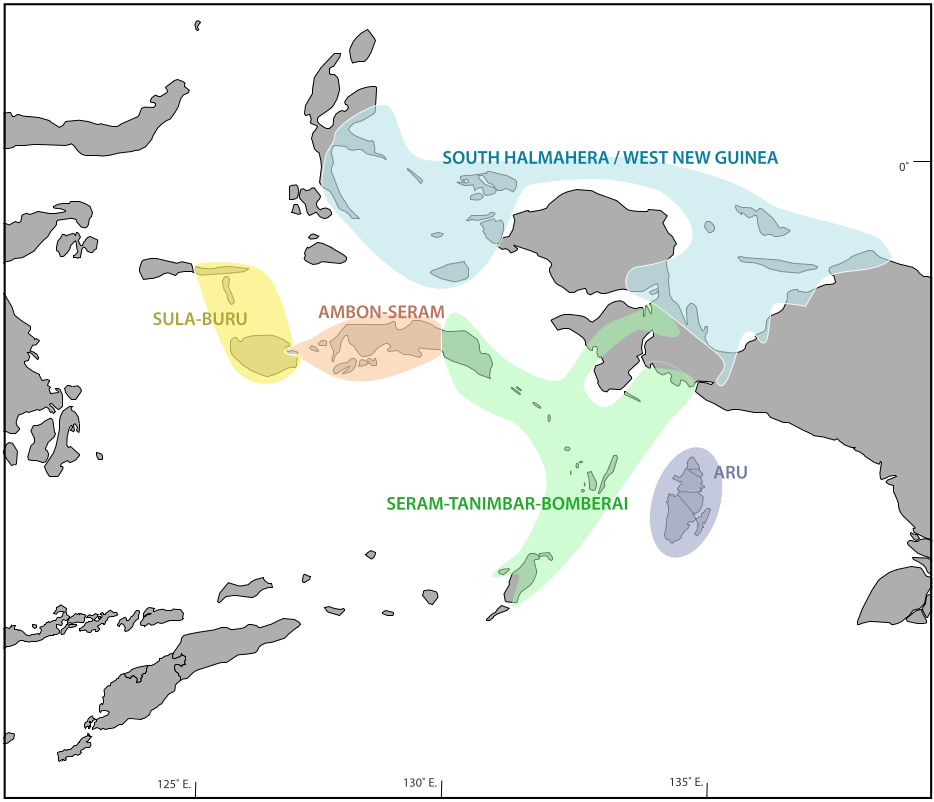

**Map 1.6:** Grimes & Edwards’ Wallacean groups mentioned in the text

### 9.2. Phonological innovations in Oceanic and Wallacean languages

It is convenient to refer to CMP and SHWNG languages together as the Austronesian languages of “linguistic Wallacea” (Schapper 2016), or, more simply in the present context, as Wallacean.

Table 1.8 shows innovations in consonants in the protolanguages of Oceanic and various Wallacean subgroups including SHWNG and others clustered close to it.[^41] The table makes no reference to innovations that occur in smaller subgroups within those shown. Often one or more of the innovations listed in the table does not occur in a subgroup’s parent language but does occur in lower-order subgroup(s) within it. This is part and parcel of the Wallacean pattern of shared innovations whereby isoglosses intersect, forming possible linkages. However, close inspection of the innovations shows that they affect certain PMP consonants across two or more Wallacean groups, suggesting that drift resulting from pressures on similar consonant systems is as likely a cause as shared inheritance.

**Table 1.8.** Consonant innovations in the parent languages of Oceanic and Wallacean subgroups (key beneath table)

| PMP > | Oceanic | SHWNG | Ambon-Seram | Seram-Tanimbar-Bomberai | Aru | Sula-Buru |
| --- | --- | --- | --- | --- | --- | --- |
| *p > *f |  | yes | yes | yes | init |  |
| *p > *f > *h |  |  |  |  | med |  |
| *p > *b | some |  |  |  |  |  |
| *b > *p | *β | some | yes |  | yes | yes |
| *t > *s/__*i_ |  | yes |  |  |  |  |
| *mp/*mb > *ᵐb | some | yes |  | yes | ? |  |
| *mp/*mb > *ᵐp |  |  | yes |  |  |  |
| *nt/*nd > *ⁿd |  | yes | yes | yes | yes |  |
| *d > *d-r- | some | yes | yes |  |  |  |
| *d > *r | some |  |  | yes | yes | yes |
| *d > *dr [ⁿr] | some |  |  |  |  |  |
| *d/*z > *d |  |  | yes |  |  |  |
| *d/*z > *r |  |  | yes |  |  |  |
| *d/*l > *r |  | yes |  |  |  |  |
| *-j-/*s > *s |  | yes |  |  |  |  |
| *-j-/*s > *j [ɟ] | some |  |  |  |  |  |
| *-j-/*l > *l |  |  | yes |  |  | some |
| *-j- > 0̸ |  |  |  |  |  | some |
| *-j-/*R > *R |  |  | yes |  | yes |  |
| *z/*s > *s | yes |  |  |  |  |  |
| *z/*y merge |  |  |  |  | yes |  |
| *ŋ > *n |  |  | yes |  |  |  |
| *q > *0̸ |  | yes | some |  | yes | yes |
| *qa- etc lost |  | yes | some |  | yes | yes |

- ‘some’ indicates that the change unpredictably applies to some etyma but not others;
- an empty cell means ‘no’.

The innovation listed as ‘*qa- etc lost’ in the bottom row of Table 1.8 needs an explanation. It refers to the fact that words of three or more syllables of which the first PMP syllable was *qa- or *ha- regularly lose that syllable in most Wallacean languages. This loss is probably associated with the loss of *q- or *h-, which is almost universal in Wallacean languages. Just one language, Watubela of the Seram-Tanimbar-Bomberai group, clearly retains *q as *k*, meaning that its retention must be reconstructed to Proto Seram-Tanimbar-Bomberai. Thus, for example, PMP *qateluR ‘egg’ is regularly reflected as POc *qatoluR (vol.4:278–279) and Watubela *katlu*, but as PSHWNG *tolo (Taba *tolo*, Mayá *tól*, Umar *tor*), Uyir *tuli* (Aru), Maswiang *tolin* (STB), Paulohi *terur* (AS).

What mainly concerns us in Table 1.8 is not the details of the innovations but their patterning and particularly the considerable differences between Oceanic and the Wallacean groups. It is immediately clear that SHWNG innovations pattern more closely with those of other Wallacean subgroups, and barely at all with Oceanic.

As for the innovations of Oceanic, only one, the merger of PMP *s and *z as POc *s, is shared with a Wallacean group, Central Timor, far away from Oceanic. This is presumably a case of independent parallel innovation.

An obvious feature of POc in Table 1.8 is the number of cells containing ‘some’, indicating that the change applied to only some etyma. These refer to the obstruent splits noted in Table 1.6 and the associated discussion in §1.8.2.1 and §1.8.2.3.

Their significance here is that the merger-then-split pattern that gave rise to POc obstruent pairs has not occurred in the history of any Wallacean group. Table 1.9 shows PMP obstruents along with their PSHWNG and POc reflexes. The PSHWNG column shows one reflex for each PMP obstruent and for each PMP pair of nasal + obstruent clusters. This organisation is representative of all Wallacean groups as Grimes & Edwards (in prep.) reconstruct their histories. The POc column, however, shows the pairs of reflexes discussed earlier.

As an example, Figure 1.7 sets out the changes in PMP *p and *b, as they are reflected in PSHWNG and in POc. The PSHWNG changes are simple, and are similar to those in other Wallacean languages. The POc changes are more complex. Both PSHWNG and ePOc have three labial consonants, but they have developed along different routes.[^42]

**Table 1.9.** PMP obstruents and their PSHWNG and POc reflexes

|  | PMP | PSHWNG | POc |
| --- | --- | --- | --- |
| Bilabial | *p | *f | *p/*b |
|  | *b | *p | *p/*b |
|  | *-Np-/*-Nb- | *b | *p/*ᵐb |
| Dental | *t | *t | *t |
|  | *-Nt- | *d | *ⁿd |
| Alveolar | *d | *r | *r/*dr |
|  | *-Nd- | *d | *dr |
| Alveolar | *s | *s | *s/*j |
|  | *z | *z | *s/*j |
|  | *-Ns-/*-Nz- | ? | *s/*ñj ? |
| Velar | *k | *k | *k/*g ? |
|  | *g | ? | *k |
|  | *-Nk-/*-Ng- | *g | *ᵑg |

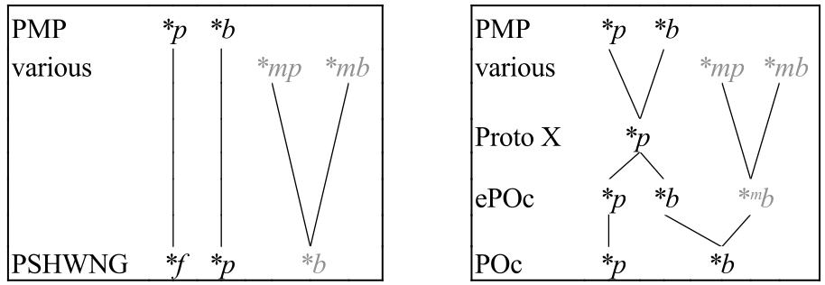

**Figure 1.7:** The phonological histories of PSHWNG and POc reflexes of PMP *p and *b

### 9.3. Conclusion: so where did Proto Oceanic come from?

Where then did Proto Oceanic come from? The phonological history that gave rise to the patterns in Table 1.9 is unlike that of the Wallacean languages and significantly more complicated. No Wallacean language—and as far as we know, no WMP language—underwent a set of obstruent mergers like those that gave rise to Proto X, followed by the set of splits that gave rise to the POc. Wallacean languages other than the Sula-Buru group, however, display a merger, of PMP *-Nt- and *-Nd-, where POc has no merger. This implies that the ancestor of POc was separate from the ancestor(s) of the Wallacean languages when the Wallacean merger occurred.

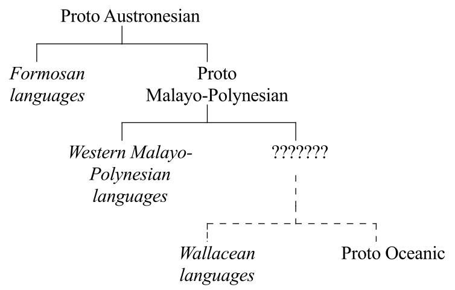

**Figure 1.8:** Schematic diagram showing the implications of our analysis for the genealogy of the Austronesian family.

Figure 1.8 shows our dilemma. Do the Wallacean languages and POc have a common ancestor? There is some lexical evidence that they do, in the shape of the PCEMP etyma in theACDand the 1978 PEMP etyma that are now known to have Wallacean cognates (§1.9.1), but, as we have observed, using lexical data in this way has disadvantages. These are matters for future research.

Meanwhile, we can say that using the lexical reconstructions in volumes 1–5 as sources for phonological history has proven to be a fitting conclusion to the present work.

## Notes

[^1]: This introduction incorporates material in the introductions to Volumes 1–5, replicated so that each volume can be used independently, but also includes new material (§1.8 and §1.9). Our presentation of Oceanic subgrouping was revised in the introduction to volume 3, and this is largely retained here. We are indebted to Charles Grimes and Owen Edwards for their comments, especially on §§1.7-1.8.
[^2]: The project, the brainchild of Andrew Pawley, has been jointly directed by him and by Malcolm Ross, with research assistance from Meredith Osmond, in the Department of Linguistics of the Research School of Pacific and Asian Studies and its successor, the College of Asia and the Pacific, at the Australian National University.
[^3]: Ethnologue (Eberhard et al. 2022) lists 513 Oceanic languages, Glottolog 4.6 (Hammarström et al. 2022) lists 521. The two Micronesian exceptions are Chamorro in the Marianas and Palau, both apparently single-language branches within western Malayo-Polynesian (see Figure 1.5). There is broad agreement that speakers of pre-Chamorro migrated from the northern Philippines, but the origin of Palauan remains a mystery (Blust 2000a; Reid 2002; Smith 2017). Zobel 2002 gives an alternative view.
[^4]: Terms for people (rather than for kinship or rank) are reconstructed in vol.5, ch.2. They include ‘person’, ‘woman’, ‘man’, age cohort terms from early childhood to old age, terms for people by absence or deprivation of relationship (‘orphan’, ‘unmarried adult’, ‘widow(er)’) and for twins.
[^5]: The 2020 ‘frozen’ACDcontinues to be stored at the University of Hawai‘i (http://www.trussel2.com/acd/), but is now also available and under development in somewhat different format as part of the Cross-Linguistic Linked Data project (https://acd.clld.org/).
[^6]: Differences in meaning are ignored here, but see §1.4.1.
[^7]: A hyphen before or after a form for ‘four’ indicates the addition of a numeral classifier (§14.1.1).
[^8]: For a lucid and concise account of the history of the matters we touch on here, and of the matters themselves, see François (2014).
[^9]: In previous volumes, Appendix B, showing the groupings of Oceanic languages, followed Ross (1988), using the term family as a synonym for subgroup. This confusing usage is abandoned here.
[^10]: In the jargon of biological phylogenetics a shared innovation is a synapomorphy.
[^11]: Figure 1.4 and the right-hand diagram of Figure 1.2 were inspired by François’ (2014) diagram 6.3.
[^12]: In this discussion of linkages, ‘language’ is used to mean ‘language or dialect’.
[^13]: ‘Eastern Fijian languages’ in Figure 1.1 is our label for Geraghty’s (1983) ‘Tokalau Fijian’.
[^14]: WOc also includes the Sarmi/Jayapura (SJ) group (see Map 1.1). It may belong to the NNG linkage, but this is uncertain Ross (1996b).
[^15]: A second Oceanic reflex, ’Are’are *rapi* ‘a twin; two stones in one fruit’, was later added in theACD.
[^16]: Bearers of the Lapita culture had settled various parts of the Bismarck Archipelago by around 1400 BC (Specht 2007) and colonised the Reefs and Santa Cruz Is. in the Temotu Archipelago, Vanuatu and New Caledonia by about 1000 BC (Green 2003; Green, Jones & Sheppard 2008; Sand 2001b). Maybe a century later they settled in Fiji (Nunn et al. 2004; Clark & Anderson 2009). They reached Tonga by 850 BC (Burley & Connaughton 2007), Samoa by 750 BC (Clark and Anderson 2009).
[^17]: We included these nodes in the corresponding tree in Figure 1 of volumes 1 and 2, but this was too easily interpreted as a statement of our views on subgrouping..
[^18]: The term ‘Eastern Oceanic’ and the search for evidence of an Eastern Oceanic subgroup has a relatively long pedigree in Oceanic linguistics (Biggs 1965; Pawley 1972, 1977; Lynch & Tryon 1985; Geraghty 1990). However, by the time volume 1 of the present work was published in 1998 it was evident that no convincing evidence supported an Eastern Oceanic subgroup. Our use of the term here is more inclusive than most, resembling the ‘Central/Eastern Oceanic’ of Lynch & Tryon (1983) (the 1985 published version is less inclusive) and of Lynch, Ross & Crowley (2002:94–96), who express reservations about its status.
[^19]: Cases where such an inference can be made occur mostly at the boundary (in the Solomon Islands) between Western and Eastern Oceanic. Borrowing is likely (and is often reflected in unexpected sound correspondences) where an etymon occurs (i) in Western Oceanic and only in SE Solomonic languages or (ii) in SE Solomonic languages and only in the NW Solomonic languages (a subgroup within the Meso-Melanesian linkage of Western Oceanic).
[^20]: On the positions of Yapese and Mussau, see respectively Ross (1996a) and Ross (1988:315–316, 331).
[^21]: The main reason for retaining Ross’s orthography was that the electronic files initially used in this project were drawn in large part from those used in the research reported in Ross (1988).
[^22]: Tone is rare in Oceanic languages, and very rare in the data in this volume. Tonal languages are Yabem, Bukawa (both NNG), Cèmuhî, Paicî, Drubea, Kwênyii, Numèè (all five NCal).
[^23]: Geraghty (1990:91) records a small number of cases where certain Fijian dialects retain POc *R as *l*, indicating that it was retained sporadically in PCP. It is always lost in his ‘Tokalau Fijian’ and in Polynesian.
[^24]: Another convention sometimes used for this purpose is a double asterisk, e.g. **tau: we prefer the dagger on aesthetic grounds.
[^25]: We use Blust’s abbreviations for the groupings he discusses, including “CMP”. We use “central Malayo-Polynesian”, abbreviated “CMP” and “WMP” respectively for the languages of his CMP and Western Malayo-Polynesian when we want to refer to them without Blust’s subgrouping assumptions.
[^26]: Blust (1978a) redefined this label as also including the SHWNG languages.
[^27]: The notation *-uy(-) reflects the fact that there is one known case where the change to *i occurred word-medially: PMP *kamuihu (independent 2PL pronoun) > *kamuyu > POc *kamiu.
[^28]: We replace Dempwolff’s orthographies with those of Table 1.4.
[^29]: Dempwolff (1927, 1937) and Milke (1961) both used the term *Nasalverbindung* for *mp, *mb etc, translated as ‘nasal cluster’ by Milner (1965). Grace coined terms that expressed the pairedness of *p/*mp etc. The assumption that a “nasal grade” consonant reflected an earlier nasal cluster is enshrined in his POc orthography (Table 1.3).
[^30]: Grace notes in his 1990 paper that he had written the latter before he had access to Ross (1988).
[^31]: This total excludes POc reconstructions for which no ancestor was found in theACD.
[^32]: We are aware that the PCEMP reconstructions for ‘cuscus’ and ‘bandicoot’ are controversial. The POc reconstructions, however, are well supported. See further Grimes & Edwards, in prep.
[^33]: The POc digraph ‹dr› was adopted from Fijian orthography to represent POc *[nᵈr], the reflex of *dr in some Admiralties languages (Ross 1988:322) and in most Fijian dialects (Geraghty 1983:184).
[^34]: From the small amounts of data in Sheppard (2020), Nimowa appears not to have prenasalised consonants.
[^35]: PWOc *-dri reflects the nonhuman member of a human/nonhuman distinction found in the pronominal systems of a number of island languages to the west of New Guinea and adopted in Western Oceanic languages as the ordinary 3pl pronoun.
[^36]: The *b- vs *mb- split is reflected, for example, in Dena-Oenal (Rote-Meto) *boaʔ* vs *mbua*; Tetun (Timor) *fua-n* vs *bua*; Uruangnirin (STB) *pua-n* vs *buok*; Masiwang (STB) *fua-n* vs *bua*; E Kola (Aru) *fūi* vs *būi*; but not in Buru-Lisela (Sula-Buru) *fua-n* ‘fruit’, *fua* ‘betelnut’.
[^37]: Bradshaw (1978), Bugenhagen & Bugenhagen (2007b), Anderson (2007), Anderson & Ross (2002), Lincoln (1978), Ross’s fieldnotes.
[^38]: Blust offers Proto Central Malayo-Polynesian reconstructions. We take this to be a convenient fiction to accommodate the reconstruction of etyma that are reflected only in CMP languages, similar in status to PWOc and PSOc reconstructions in the present work (§1.4.4.3).
[^39]: The archaeology of Bellwood’s hypothesis is called into question by Clark & Winter (2019).
[^40]: One innovation, *sakaRu ‘reef’, is found in Ambon-Seram and in Chamorro.
[^41]: Many of these innovations are identified by Kamholz (2014) for SHWNG and by Grimes & Edwards (in prep.) for CMP languages. Four of the latter’s eight subgroups are shown. The others are the large and internally diverse Flores-Lembata and Timor-Babar subgroups with few shared innovations, the tiny Central Timor group, and their Taliabo group, related to languages of mainland Sulawesi either genealogically or through contact.
[^42]: The term “various” in Figure 1.7 refers to the fact that phonemes reflecting PMP nasal + obstruent clusters have at various times in their various Wallacean and their Oceanic histories acquired new members by various processes, for example by abbreviating the PMP stative prefix *ma- to *m- or by reduplication of a syllable with a final nasal (§1.8.2.2).